# **Aplicaciones de los Modelos No Supervisados**

**Basado en el proyecto del Módulo 4 Bootcamp de Ciencia de Datos e Inteligencia Artificial**

## Caso de estudio

Una empresa financiera tiene un nuevo producto dirigido a sus clientes con diferentes límites de crédito, por ello, es necesario dividir a los clientes en grupos más pequeños.

Desafortunadamente, los directivos no tienen idea de cuál es la cantidad óptima en la que se puede segregar a los clientes y cómo dirigir a nuevos clientes a esos grupos.

Es por eso que en este punto se te ha contratado. Para poder ejecutar tu trabajo te han compartido una base de datos que contiene las características que, según sus informes, son los más importantes para la aplicación de este programa. Consiste en seis puntos:

- **Salario mensual:** indica el ingreso mensual del cliente en pesos mexicanos.
- **Crédito tipo 1:** es un producto financiero que el cliente ha obtenido de la institución financiera; `1` significa que tiene este producto y `0` que no cuenta con él.
- **Crédito tipo 2:** es similar a las características del anterior; `1` significa que cuenta con el producto y `0` que no.
- **Límite de TC:** indica el límite de crédito de la tarjeta del cliente.
- **Años siendo cliente:** corresponde al tiempo que el cliente ha tenido una relación comercial con la institución financiera.
- **Previamente se ofreció el producto:** es la versión previa del producto e indica si el cliente se mostró interesado en obtenerlo (`1`) o no (`0`).

El archivo puede ser descargado aquí: https://drive.google.com/file/d/1wcjPCZPTMuDlyWcE1Do4-yqU5AglW_p9/view?usp=sharing

### Observaciones

El cliente requiere que le indiques la cantidad óptima de grupos en los que deberás catalogar a sus clientes. Para ello, usa el método del codo y grafícalo. Recuerda que tus clientes necesitan apoyos visuales.

Una vez que tengas la cantidad de grupos óptimos, deberás aplicar un método de *clustering*. El cliente solicita que le muestres gráficamente cómo están organizados los clientes. Para ello, usa una gráfica de dispersión o la que creas más conveniente.

Incluye, por lo menos, un índice de desempeño (*scoring*) para complementar tus análisis.

Tus visualizaciones deberán tener título y estar presentables. Puedes usar **Pyplot** o **Seaborn**.

Deberás escribir un texto explicando qué representa tu análisis. Usa un lenguaje que vaya dirigido a personas que no saben de ciencia de datos o matemáticas, esto es muy común en la realidad. Deberás hablar de tu gráfica, tus resultados y el manejo de la información, así como del beneficio de usar tu modelo.

Como reto adicional se te proprocionará un archivo en la liga siguiente: https://drive.google.com/file/d/1Nkoc-6AeC3Vzy7gfCNB_DlWTs4dXz7Ug/view?usp=sharing, la cual incluye 50 clientes más. Deberás aplicar el método que usaste para entrenar con tu primer modelo y aplicarlo en estos nuevos clientes. No olvides graficarlos (solo a los nuevos 50 clientes).

¡Éxito! Te vemos en el contenido del siguiente módulo.

```
/content/drive/My Drive/Módulo 4/Proyecto
```

# Exploración y Preprocesamiento de Datos

```
Encabezados:
     Salario  Credito_tipo_1  Credito_tipo_2  Limite_TC  Tiempo_cliente  \
0  22572.91               1               0   30136.74             0.0
1  10609.64               1               1   53623.94             0.0
2  10079.48               0               1   18135.44             0.0
3  13871.35               1               0   30831.75             0.0
4   6541.46               0               1   20626.23             0.0

   Producto_ofrecido
0                  1
1                  1
2                  0
3                  1
4                  0


Estadísticos:
             Salario  Credito_tipo_1  Credito_tipo_2      Limite_TC  \
count    500.000000      500.000000      500.000000     500.000000
mean   12089.097380        0.610000        0.458000   44784.554960
std     5123.700116        0.488238        0.498732   22150.923996
min    -2911.650000        0.000000        0.000000  -22207.950000
25%     8534.350000        0.000000        0.000000   30096.285000
50%    11438.600000        1.000000        0.000000   47991.515000
75%    15171.467500        1.000000        1.000000   59108.175000
max    30041.400000        1.000000        1.000000  118636.820000

       Tiempo_cliente  Producto_ofrecido
count      500.000000         500.000000
mean         4.327000           0.602000
std          4.784776           0.489976
min          0.000000           0.000000
25%          0.000000           0.000000
50%          0.000000           1.000000
75%          8.400000           1.000000
max         19.300000           1.000000


Incompletitud:
 Salario              0
Credito_tipo_1       0
Credito_tipo_2       0
Limite_TC            0
Tiempo_cliente       0
Producto_ofrecido    0
dtype: int64
```

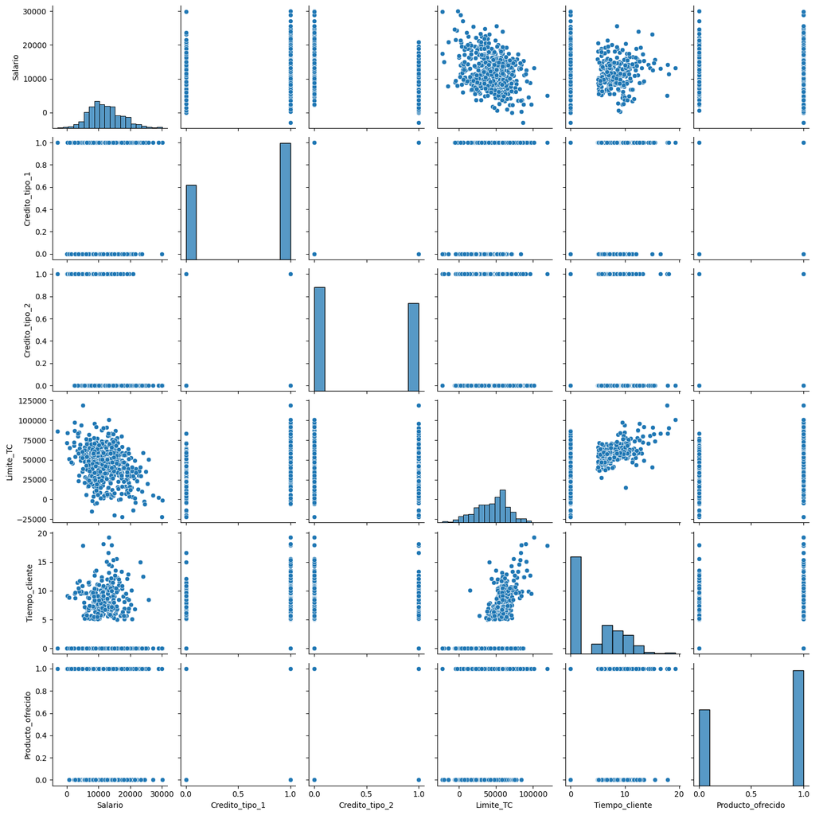

# Determinación del Número Óptimo de Grupos (Clusters)

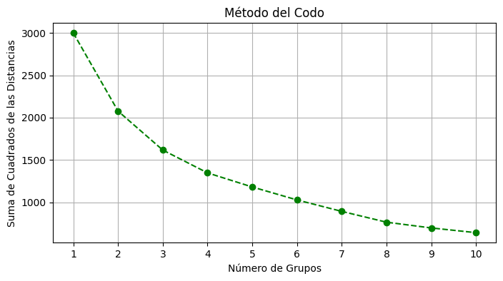

# Aplicación del Algoritmo de Clustering

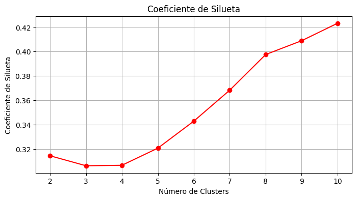

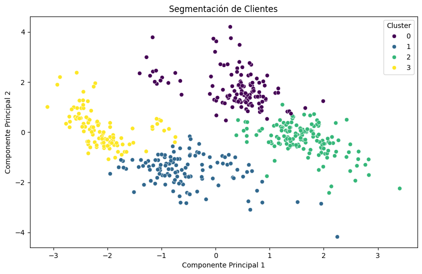

```
Coeficiente de Silueta: 0.30693
```

El análisis de clustering permite segmentar a los clientes en grupos homogéneos con respecto a las características proporcionadas.

Posteriormente, utilizo el algoritmo de Análisis de Componentes Principales (PCA) para visualizar los datos en 2 dimensiones y facilitar la interpretación.

El gráfico de dispersión muestra la distribución de los clientes en función de los dos primeros componentes principales, coloreados por el cluster al que pertenecen.

# Extra

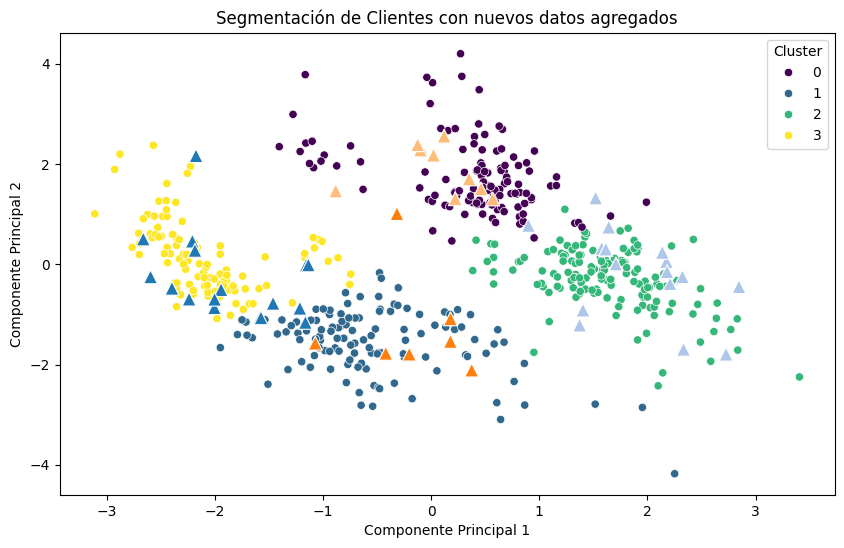

[output not shown]